# Guided Project: New York Solar Resource Data

We want to look at the Solar Resource data. This data is about various solar data types for a location. Specifically, we’ll work with these output fields:

The Average Direct Normal Irradiance(avg_dni): Direct Normal Irradiance is the amount of solar radiation a surface receives per unit area. The Average Tilt at Latitude (avg_lat_tilt): Tilt at Latitude is the amount of radiation a surface receives per unit area that doesn’t arrive on a direct path from the sun. The Average Global Horizontal Irradiance(avg_ghi): Global Horizontal Irradiance is the total amount of shortwave radiation a surface horizontal to the ground receives from above. Our goal: we want to extract the solar resource data for New York City in JSON format and convert it into a dataframe.

Instructions

Store your API key in a variable. Identify and store the API URL we’ll need to extract the New York City Solar Resource data in JSON format. Store the three parameters to request the New York City solar data as a list.

The api_key parameter contains your API key. The latitude (lat) of New York City is 41. The longitude (lon) of New York City is -75. Save the list as parameters_list.

```r
parameters_list
```

```
$api_key
[1] "0odcm1CVeOPbYmGU4wFQTblSm0yFgorVJsAULpKj"

$lat
[1] 41

$lon
[1] -75
```

Instructions

Load the httr package. Use the GET() function to request the data from the API with url and parameters_list. Track errors. Display the status code with the status_code() function. Display the API response format. Extract the API response content as text. Display this content, and check it.

```r
str(content)
```

```
 chr "{\"version\":\"1.0.0\",\"warnings\":[],\"errors\":[],\"metadata\":{\"sources\":[\"Perez-SUNY/NREL, 2012\"]},\"i"| __truncated__
```

Instructions

Parse the API response content to an R object using the jsonlite::fromJSON() function.

Store the result as json_lists. Display the structure of the R object using the str() function.

```r
str(complex_list)
```

[output not shown]

```r
str(json_list)
```

[output not shown]

Instructions

Extract the outputs list from json_lists. Extract the monthly vector (monthly) from the following lists:

avg_dni avg_ghi avg_lat_tilt. Combine the monthly vectors into a dataframe using the tibble::tibble() function.

Add the month column containing month abbreviations: Jan, Feb, . . . ,Dec.

The month column should appear on the left side of the dataframe. Save the result as dataframe.

Display the dataframe.

What do you notice, and what impact can this have on future uses of this dataframe?

```r
complex_list$c
```

```
 [1] "Jan" "Feb" "Mar" "Apr" "May" "Jun" "Jul" "Aug" "Sep" "Oct" "Nov" "Dec"
```

[output not shown]

[output cut: 2 more lines]

```r
complex_list <- list(a = 2, b = list( u = list(p = list(x = 1:3), q = list(x = 3:5))), c = month.abb)
str(complex_list)
```

```
List of 3
 $ a: num 2
 $ b:List of 1
  ..$ u:List of 2
  .. ..$ p:List of 1
  .. .. ..$ x: int [1:3] 1 2 3
  .. ..$ q:List of 1
  .. .. ..$ x: int [1:3] 3 4 5
 $ c: chr [1:12] "Jan" "Feb" "Mar" "Apr" ...
```

Instructions

Extract the outputs list from json_lists. Simplify the outputs list. Restructure the simplified list into a matrix of 13 rows (the annual value and the 12 months’ values). Remove the annual values (the first row) from the data matrix. Convert the matrix into a dataframe using the as.data.frame() function. Display the dataframe.

What difference do you see

```r
u_list <- unlist(complex_list$b$u)
u_list
```

```
p.x1 p.x2 p.x3 q.x1 q.x2 q.x3
   1    2    3    3    4    5
```

```r
# Restructuring the new list into a matrix
u_matrix <- matrix(u_list, nrow = 3)
u_matrix
```

```
     [,1] [,2]
[1,]    1    3
[2,]    2    4
[3,]    3    5
```

```r
# Converting the matrix into a dataframe
df <- as.data.frame(u_matrix)
df
```

| V1 | V2 |
| --- | --- |
| 1 | 3 |
| 2 | 4 |
| 3 | 5 |

```r
# Removing the second row
df[-2, ]
```

|  | V1 | V2 |
| --- | --- | --- |
| 1 | 1 | 3 |
| 3 | 3 | 5 |

```r
# Removing the first and second rows
df[c(-1, -2), ]
```

|  | V1 | V2 |
| --- | --- | --- |
| 3 | 3 | 5 |

```r
# Filtering df where V2 is odd using the `filter()` function from the `dplyr` package
library(dplyr)
df %>% filter(V2 %% 2 == 1)
```

| V1 | V2 |
| --- | --- |
| 1 | 3 |
| 3 | 5 |

```r
NA
NA
```

[output not shown]

[output cut: 2 more lines]

Instructions

Load the packages: httr and dplyr.

Create the custom nrel_api_json_get_df() function based on what we did in previous lessons.

Copy-paste and modify it accordingly for this purpose. Convert the content into a dataframe. Use the custom nrel_api_json_get_df() function to extract the solar resource as a dataframe.

Provide the “api/solar/solar_resource/v1.json” as the endpoint parameter. Provide the parameters_list variable as queries parameter. Save the result as solar_resource_df.

| month | avg_dni | avg_ghi | avg_lat_tilt |
| --- | --- | --- | --- |
| Jan | 3.12 | 1.97 | 3.55 |
| Feb | 3.36 | 2.69 | 4.04 |
| Mar | 4.10 | 3.86 | 4.86 |
| Apr | 4.07 | 4.70 | 4.97 |
| May | 4.15 | 5.45 | 5.18 |
| Jun | 4.17 | 5.78 | 5.24 |
| Jul | 4.60 | 5.98 | 5.58 |
| Aug | 4.14 | 5.14 | 5.24 |
| Sep | 4.02 | 4.23 | 5.00 |
| Oct | 3.26 | 2.94 | 4.11 |

[output cut: 2 more lines]

Instructions

Load the ggplot2 and dplyr packages.

Create the first plot with the following settings:

Use the ggplot() function to plot (for each month) the average direct irradiation (avg_dni) from solar_resource_df. Use geom_line() and geom_point() functions to get a line plot with a dot for each value. Use the theme_bw() theme. Create the second plot with the following settings:

Convert the month column into a factor using the following command: solar_resource_df <- solar_resource_df %>% mutate(month = factor(month, levels = month.abb)). Reproduce the first plot with the same settings. You can copy-paste the first plot code snippet. What do you notice comparing both plots?

What have you learned about this command solar_resource_df <- solar_resource_df %>% mutate(month = factor(month, levels = month.abb))?

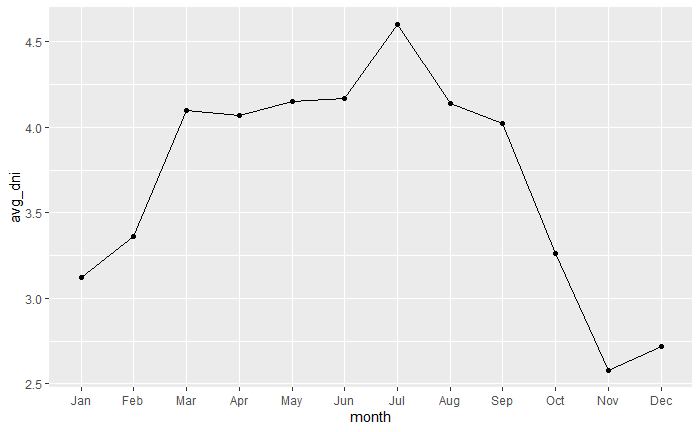

We notice that solar irradiation is the highest in New York City around July. This period corresponds to summer.

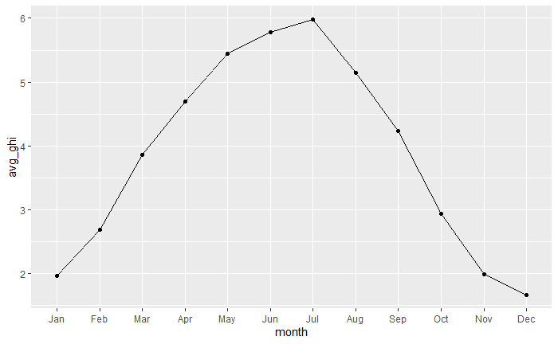